# Reproducible Research: Peer Assessment 1

## Loading and preprocessing the data

```r
# Load packages
library(ggplot2)
library(lattice)

# Load original file and ??
df <- read.csv(file = "activity.csv", stringsAsFactors = FALSE)
df$date <- as.Date(df$date,"%Y-%m-%d") # Format the date
```

## What is mean total number of steps taken per day?

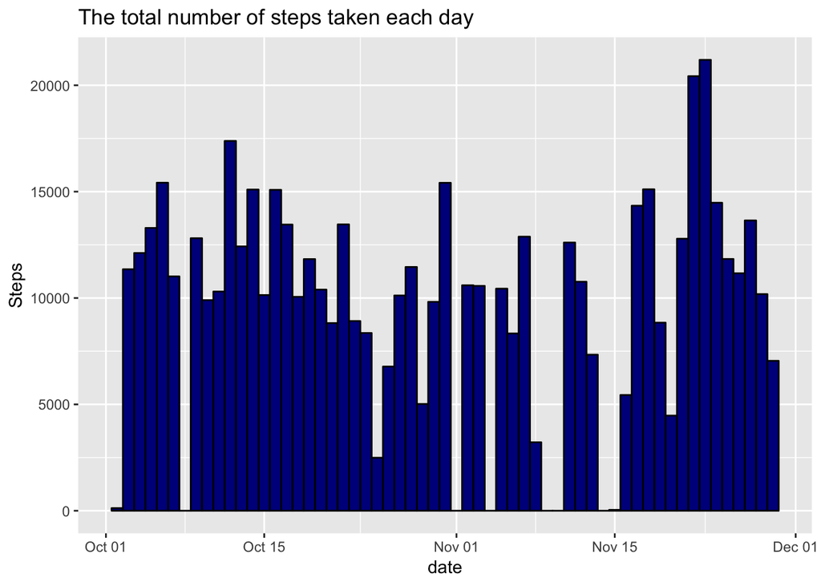

```r
# Total Steps By Day
steps_per_day <- aggregate(steps ~ date, df, sum)

# Plot
g <- ggplot(steps_per_day, aes(x = date))
g + geom_histogram(aes(weight = steps), binwidth = 1, color = "black", fill="darkblue") +
    ggtitle("The total number of steps taken each day") + ylab("Steps")
```

```r
# Mean & Median
options(scipen=999)
Mean <- round(mean(steps_per_day$steps),4)
Median <- round(median(steps_per_day$steps),4)
```

The mean total number of steps taken per day is 10766.1887. The median total number of steps taken per day is 10765.

## What is the average daily activity pattern?

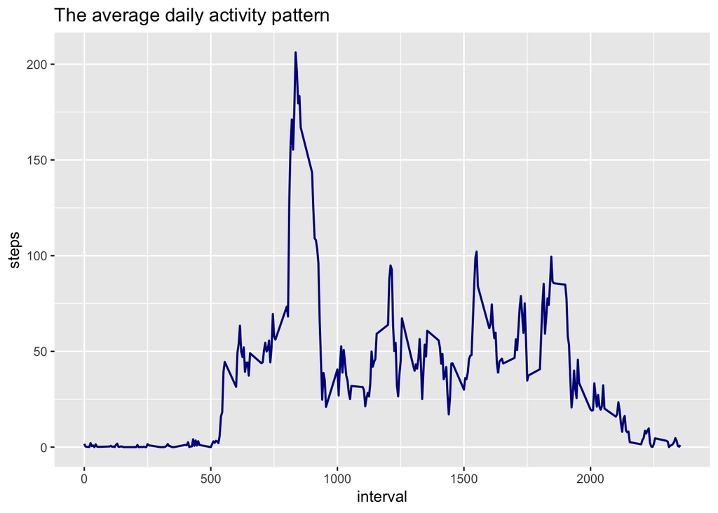

```r
# Avg Steps By Interval
avg_steps <- aggregate(steps ~ interval, df, mean)

# Plot
g <- ggplot(avg_steps, aes(x = interval, y = steps))
g + geom_line(color = "darkblue", lwd=0.7) + ggtitle("The average daily activity pattern")
```

```r
# Interval with max average steps
max_interval <- avg_steps$interval[which.max(avg_steps$steps)]
```

The 5-minute interval, that contains the maximum average number of steps is 835.

## Imputing missing values

```r
Complete <- complete.cases(df)
Missing_Value <- sum(!Complete)
```

The total number of rows with NAs is 2304.

Here is the the code, that fills all the missing values with the mean for that 5-minute interval.

```r
df_new <- df

# check if steps equal to NA, if TRUE, fill in data mean for that 5-minute interval
for(i in 1:nrow(df)) {
    if (is.na(df[i,1])) {
        df_new[i,1] <- avg_steps[which(avg_steps$interval == df[i,3]),2]
    }
}
```

This is a histogram of the total number of steps taken each day.

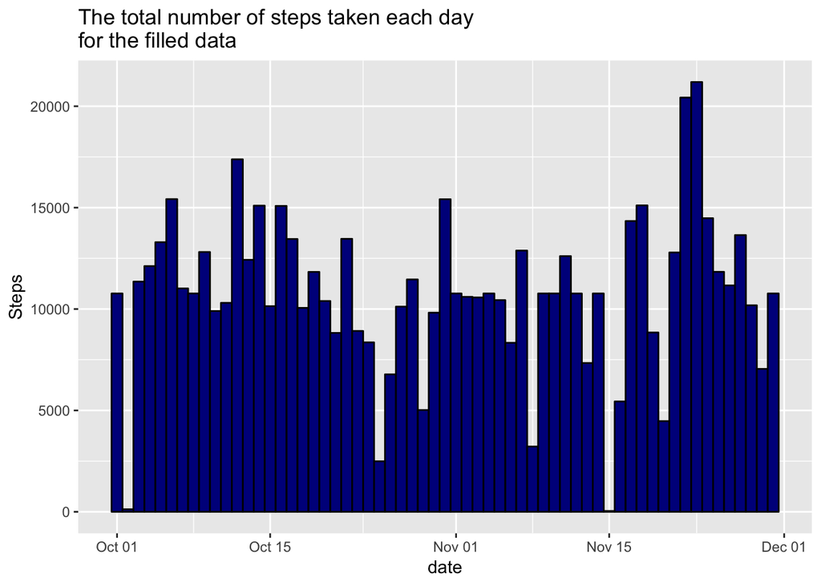

```r
steps_per_day_new <- aggregate(steps ~ date, df_new, sum)

# plot
g <- ggplot(steps_per_day_new, aes(x = date))
g + geom_histogram(aes(weight = steps), binwidth = 1, color = "black", fill="darkblue") +
    ggtitle("The total number of steps taken each day\nfor the filled data") + ylab("Steps")
```

```r
# Mean & Median
Mean_new <- mean(steps_per_day_new$steps)
Median_new <- median(steps_per_day_new$steps)
```

The mean total number of steps taken per day for the filled data is 10766.1886792. The median total number of steps taken per day for the filled data is 10766.1886792.

The mean number of steps taken per day are the same. However, the median number of steps taken per day are slightly different. Owing to filling missing values by the mean of 5 minute interval.

## Are there differences in activity patterns between weekdays and weekends?

```r
# Create a new factor variable in the dataset with two levels ??? ???weekday??? and ???weekend??? indicating whether a given date is a weekday or weekend day.
df_week <- df
df_week$week <- weekdays(df_week$date)
df_week[which(!df_week$week %in% c("Sunday","Saturday")),]$week <- c("Weekdays")
df_week[which(df_week$week %in% c("Sunday","Saturday")),]$week <- c("Weekend")
```

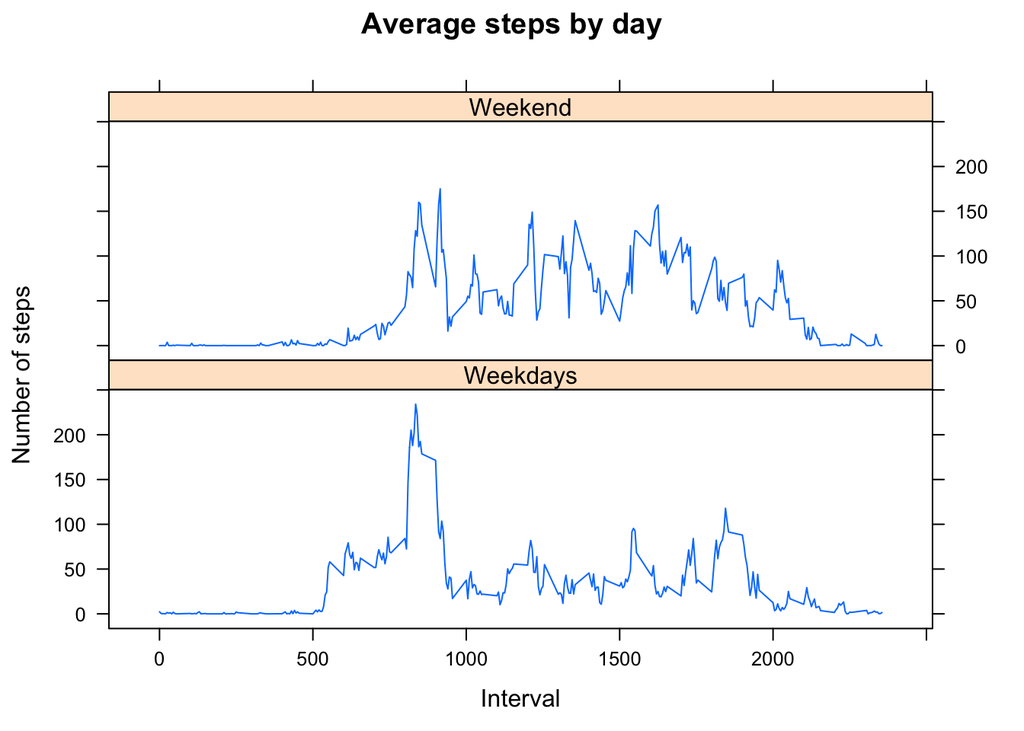

```r
## Make a panel plot containing a time series plot (i.e. type = "l") of the 5-minute interval (x-axis) and the average number of steps taken, averaged across all weekday days or weekend days (y-axis).
# Avg Steps By Interval & Day.type
avg_steps_interval_and_week <- aggregate(steps ~ week + interval, df_week, mean)

# Plot

xyplot(steps ~ interval | week, data = avg_steps_interval_and_week, type='l', layout = c(1, 2),
       xlab = 'Interval', ylab='Number of steps', main = 'Average steps by day')
```

According to the plot the main difference between the activity patterns is the maximum value. Weekend activity pattern does not have a big “pike” about the 835 interval. Also the mean value for the weekend is a bit higher because there are more values between 100 and 150 than in the weekday pattern.